# CodeBook_plots

Mike Lakoju

18 April 2016

This assignment uses data from the UC Irvine Machine Learning Repository, a popular repository for machine learning datasets. In particular, we will be using the “Individual household electric power consumption Data Set” which I have made available on the course web site:

Dataset: Electric power consumption [20Mb] Description: Measurements of electric power consumption in one household with a one-minute sampling rate over a period of almost 4 years. Different electrical quantities and some sub-metering values are available. The following descriptions of the 9 variables in the dataset are taken from the UCI web site:

Date: Date in format dd/mm/yyyy Time: time in format hh:mm:ss Global_active_power: household global minute-averaged active power (in kilowatt) Global_reactive_power: household global minute-averaged reactive power (in kilowatt) Voltage: minute-averaged voltage (in volt) Global_intensity: household global minute-averaged current intensity (in ampere) Sub_metering_1: energy sub-metering No. 1 (in watt-hour of active energy). It corresponds to the kitchen, containing mainly a dishwasher, an oven and a microwave (hot plates are not electric but gas powered). Sub_metering_2: energy sub-metering No. 2 (in watt-hour of active energy). It corresponds to the laundry room, containing a washing-machine, a tumble-drier, a refrigerator and a light. Sub_metering_3: energy sub-metering No. 3 (in watt-hour of active energy). It corresponds to an electric water-heater and an air-conditioner.

## After downloading the data file, Read the dataset into R:

```r
data<-read.table("household_power_consumption.txt",header = TRUE, sep= ";")
```

### Look at the attributes of the datset:

```r
names(data)
```

```
## [1] "Date"                  "Time"                  "Global_active_power"
## [4] "Global_reactive_power" "Voltage"               "Global_intensity"
## [7] "Sub_metering_1"        "Sub_metering_2"        "Sub_metering_3"
```

```r
lapply(data, class)
```

```
## $Date
## [1] "factor"
##
## $Time
## [1] "factor"
##
## $Global_active_power
## [1] "factor"
##
## $Global_reactive_power
## [1] "factor"
##
## $Voltage
## [1] "factor"
##
## $Global_intensity
## [1] "factor"
##
## $Sub_metering_1
## [1] "factor"
##
## $Sub_metering_2
## [1] "factor"
##
## $Sub_metering_3
## [1] "numeric"
```

## Let’s use strptime to change the factor Date and Time values in to yyyy-mm-dd hh:mm:ss. First, let’s create a variables by concatenating Date and Time.

```r
data$DateTime<-paste(data$Date, data$Time)
```

## Next chnage DateTime to yyyy-mm-dd hh:mm:ss

```r
data$DateTime<-strptime(data$DateTime, "%d/%m/%Y %H:%M:%S")
```

## Let’s work with the data for dates 2007-02-01 and 2007-02-02.

```r
start<-which(data$DateTime==strptime("2007-02-01", "%Y-%m-%d"))

end<-which(data$DateTime==strptime("2007-02-02 23:59:00", "%Y-%m-%d %H:%M:%S"))

data2<-data[start:end,]
```

# Plot1 .

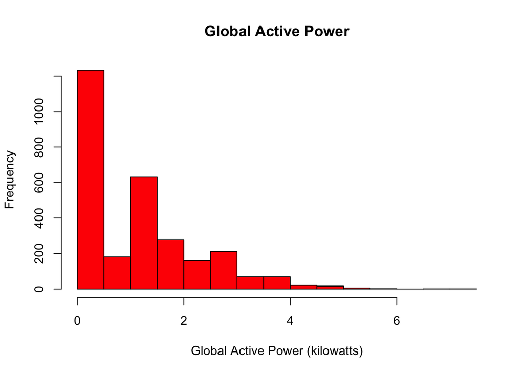

```r
hist(as.numeric(as.character(data2$Global_active_power)), # note we used as.character and as numeric since
     # the variable is factor variable.
     main="Global Active Power",
     xlab="Global Active Power (kilowatts)", col="red")
```

# Plot 2

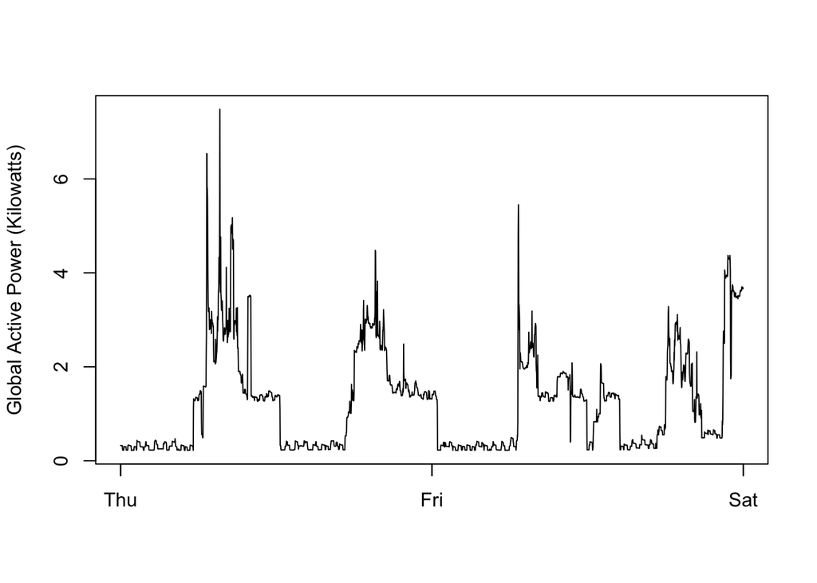

```r
plot(data2$DateTime, as.numeric(as.character(data2$Global_active_power)),
     type='l',ylab="Global Active Power (Kilowatts)", xlab="")
```

# Plot 3

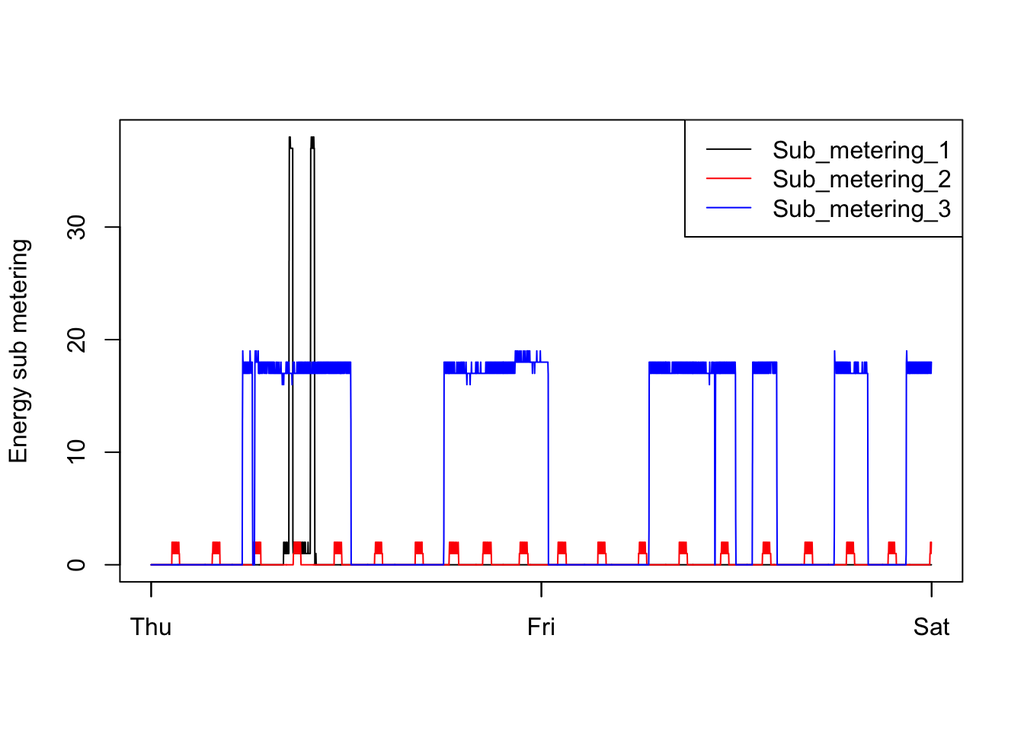

```r
plot(data2$DateTime, as.numeric(as.character(data2$Sub_metering_1)),type='l',
     ylab ="Energy sub metering", xlab="")
 lines(data2$DateTime, as.numeric(as.character(data2$Sub_metering_2)),type='l', col='red')
 lines(data2$DateTime, data2$Sub_metering_3,type='l', col="blue")
  legend('topright', c("Sub_metering_1","Sub_metering_2","Sub_metering_3"),
                    lty=c(1,1,1)
                    ,col=c("black","red","blue"))
```

# Plot 4

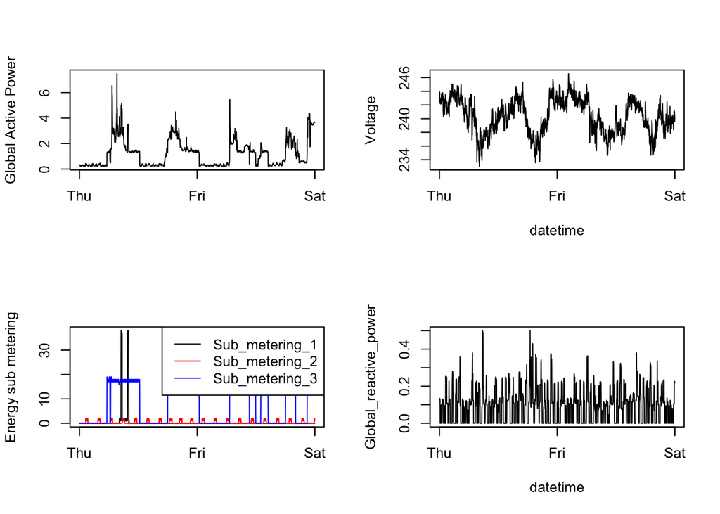

```r
par(mfcol=c(2,2))

plot(data2$DateTime, as.numeric(as.character(data2$Global_active_power)),type='l',ylab="Global Active Power", xlab="")

plot(data2$DateTime, as.numeric(as.character(data2$Sub_metering_1)),type='l', xlab="",ylab ="Energy sub metering")
lines(data2$DateTime, as.numeric(as.character(data2$Sub_metering_2)),type='l', col='red')
lines(data2$DateTime, data2$Sub_metering_3,type='l', col="blue")
legend('topright', c("Sub_metering_1","Sub_metering_2","Sub_metering_3"),
       lty=c(1,1,1),col=c("black","red","blue"))

plot(data2$DateTime, as.numeric(as.character(data2$Voltage)),type='l',
     ylab="Voltage",xlab="datetime" )

plot(data2$DateTime, as.numeric(as.character(data2$Global_reactive_power)),type='l',
     ylab="Global_reactive_power",xlab="datetime" )
```